# project-v1

### Install packages

```python
!pip install -U pip
!pip install -U setuptools wheel
!pip install -U "mxnet<2.0.0" bokeh==2.0.1
!pip install autogluon --no-cache-dir
# Without --no-cache-dir, smaller aws instances may have trouble installing
```

### Setup kaggle API key

```python
# create the .kaggle directory
!mkdir -p ~/.kaggle

# create an empty kaggle.json file
!touch ~/.kaggle/kaggle.json

# change permission so only owner has read and write access
!chmod 600 ~/.kaggle/kaggle.json
```

```python
# edit the kaggle.json file to have username name and api token

import json
kaggle_username = "everylittlething"
kaggle_key = "6a0affd4655a570993d8091ab97a7b5b"

with open("/home/studio-lab-user/.kaggle/kaggle.json", "w") as f:
    f.write(json.dumps({"username": kaggle_username, "key": kaggle_key}))
```

### Download the dataset

```python
# download the dataset
!kaggle competitions download -c bike-sharing-demand
```

```python
# unzip the dataset
!unzip -o bike-sharing-demand.zip
```

#### import the necessary modules

```python
import pandas as pd
import numpy as np
import matplotlib.pyplot as plt
%matplotlib inline
from autogluon.tabular import TabularPredictor
```

### Create the training and testing dataset

```python
train = pd.read_csv("train.csv", parse_dates = ["datetime"])
train.head()
```

|  | datetime | season | holiday | workingday | weather | temp | atemp | humidity | windspeed | casual | registered | count |
| --- | --- | --- | --- | --- | --- | --- | --- | --- | --- | --- | --- | --- |
| 0 | 2011-01-01 00:00:00 | 1 | 0 | 0 | 1 | 9.84 | 14.395 | 81 | 0.0 | 3 | 13 | 16 |
| 1 | 2011-01-01 01:00:00 | 1 | 0 | 0 | 1 | 9.02 | 13.635 | 80 | 0.0 | 8 | 32 | 40 |
| 2 | 2011-01-01 02:00:00 | 1 | 0 | 0 | 1 | 9.02 | 13.635 | 80 | 0.0 | 5 | 27 | 32 |
| 3 | 2011-01-01 03:00:00 | 1 | 0 | 0 | 1 | 9.84 | 14.395 | 75 | 0.0 | 3 | 10 | 13 |
| 4 | 2011-01-01 04:00:00 | 1 | 0 | 0 | 1 | 9.84 | 14.395 | 75 | 0.0 | 0 | 1 | 1 |

```python
#verify the dtype of the datetime column
train.info()
```

```python
test = pd.read_csv("test.csv", parse_dates = ["datetime"])
test.head()
```

|  | datetime | season | holiday | workingday | weather | temp | atemp | humidity | windspeed |
| --- | --- | --- | --- | --- | --- | --- | --- | --- | --- |
| 0 | 2011-01-20 00:00:00 | 1 | 0 | 1 | 1 | 10.66 | 11.365 | 56 | 26.0027 |
| 1 | 2011-01-20 01:00:00 | 1 | 0 | 1 | 1 | 10.66 | 13.635 | 56 | 0.0000 |
| 2 | 2011-01-20 02:00:00 | 1 | 0 | 1 | 1 | 10.66 | 13.635 | 56 | 0.0000 |
| 3 | 2011-01-20 03:00:00 | 1 | 0 | 1 | 1 | 10.66 | 12.880 | 56 | 11.0014 |
| 4 | 2011-01-20 04:00:00 | 1 | 0 | 1 | 1 | 10.66 | 12.880 | 56 | 11.0014 |

```python
test.info()
```

```python
# drop the registered and casual columns as they are not included in the test dataset
train.drop(labels =['casual', 'registered'], axis = 'columns', inplace=True)
train.info()
```

```
<class 'pandas.core.frame.DataFrame'>
RangeIndex: 10886 entries, 0 to 10885
Data columns (total 10 columns):
 #   Column      Non-Null Count  Dtype
---  ------      --------------  -----
 0   datetime    10886 non-null  datetime64[ns]
 1   season      10886 non-null  int64
 2   holiday     10886 non-null  int64
 3   workingday  10886 non-null  int64
 4   weather     10886 non-null  int64
 5   temp        10886 non-null  float64
 6   atemp       10886 non-null  float64
 7   humidity    10886 non-null  int64
 8   windspeed   10886 non-null  float64
 9   count       10886 non-null  int64
dtypes: datetime64[ns](1), float64(3), int64(6)
memory usage: 850.6 KB
```

```python
submission = pd.read_csv("sampleSubmission.csv")
submission.head()
```

|  | datetime | count |
| --- | --- | --- |
| 0 | 2011-01-20 00:00:00 | 0 |
| 1 | 2011-01-20 01:00:00 | 0 |
| 2 | 2011-01-20 02:00:00 | 0 |
| 3 | 2011-01-20 03:00:00 | 0 |
| 4 | 2011-01-20 04:00:00 | 0 |

## Training my first AutoGluon Model

Requirements:

- We are predicting `count`, so it is the label we are setting.
- Ignore `casual` and `registered` columns as they are also not present in the test dataset.
- Use the `root_mean_squared_error` as the metric to use for evaluation.
- Set a time limit of 10 minutes (600 seconds).
- Use the preset `best_quality` to focus on creating the best model.

```python
initial_predictor = TabularPredictor(label = "count", eval_metric="root_mean_squared_error").fit(
    train_data = train,
    time_limit = 600,
    presets = "best_quality"
)
```

### Review and Visulaize Performance of Models

```python
initial_results = initial_predictor.fit_summary()
```

```python
initial_predictor.leaderboard(silent=True).plot(kind = "bar", x="model", y= "score_val")
```

### Create predictions from test dataset to submit to kaggle

```python
predictions = initial_predictor.predict(test)
predictions.head()
```

```python
#remove any negative values, as they are not allowed. replace negative values with zero
(predictions < 0).sum()
```

```python
def replaceNegative(x):
    if x < 0:
        return 0
    return x
```

```python
predictions.apply(replaceNegative)
(predictions < 0).sum()
```

```python
submission['count'] = predictions
submission.to_csv("submission.csv", index=False)
```

#### Submit submissions.cvs

```python
!kaggle competitions submit -c bike-sharing-demand -f submission.csv -m "first raw submission"
```

#### Review initial score

```python
!kaggle competitions submissions -c bike-sharing-demand | tail -n +1 | head -n 6
```

```python
initial_score = 1.73373
```

## Step 4: Exploratory Data Analysis and Creating an additional feature

- Any additional feature will do, but a great suggestion would be to separate out the datetime into hour, day, or month parts.

```python
train.hist(figsize=(12,12), xrot = 90)
```

```python
# create hour day and month feature
train['month'] = train['datetime'].dt.month
train['day'] = train['datetime'].dt.day
train['hour'] = train['datetime'].dt.hour

test['month'] = test['datetime'].dt.month
test['day'] = test['datetime'].dt.day
test['hour'] = test['datetime'].dt.hour
```

## Make category types for these so models know they are not just numbers

- AutoGluon originally sees these as ints, but in reality they are int representations of a category.
- Setting the dtype to category will classify these as categories in AutoGluon.

```python
train["season"] = train['season'].astype('category')
train["weather"] = train['weather'].astype('category')
test["season"] = test['season'].astype('category')
test["weather"] = test['weather'].astype('category')
```

```python
train.info()
```

```python
train.head()
```

```python
test.info()
```

```python
test.head()
```

```
array([[<AxesSubplot: title={'center': 'datetime'}>,
        <AxesSubplot: title={'center': 'holiday'}>,
        <AxesSubplot: title={'center': 'workingday'}>],
       [<AxesSubplot: title={'center': 'temp'}>,
        <AxesSubplot: title={'center': 'atemp'}>,
        <AxesSubplot: title={'center': 'humidity'}>],
       [<AxesSubplot: title={'center': 'windspeed'}>,
        <AxesSubplot: title={'center': 'count'}>,
        <AxesSubplot: title={'center': 'month'}>],
       [<AxesSubplot: title={'center': 'day'}>,
        <AxesSubplot: title={'center': 'hour'}>, <AxesSubplot: >]],
      dtype=object)
```

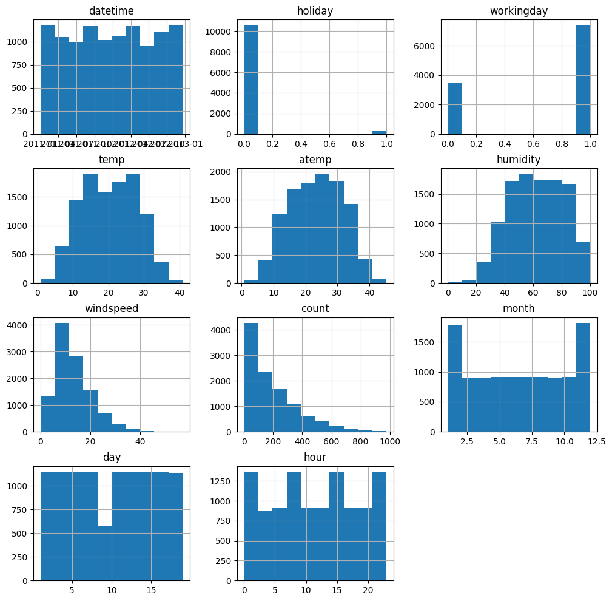

```python
train.hist(figsize=(12,12))
```

## Step 5: Rerun the model with the same settings as before, just with more features

```python
predictor_new_features = TabularPredictor(label = 'count', eval_metric = 'root_mean_squared_error').fit(
    train_data = train,
    time_limit = 600,
    presets = "best_quality"
)
```

```python
predictor_new_features.fit_summary()
```

```python
predictor_new_features.leaderboard(silent=True).plot(kind='bar', x='model', y='score_val')
```

### Make predictions on the test data using the new predictor

```python
predictions_new_features = predictor_new_features.predict(test)
```

```python
print((predictions_new_features < 0).sum())
# remove any negative values
predictions_new_features = predictions_new_features.apply(replaceNegative)
print((predictions_new_features < 0).sum())
```

### Sumbit predictions using new features

```python
submission_new_features = submission
```

```python
submission_new_features['count'] = predictions_new_features
submission_new_features.to_csv('submission_new_features.csv', index=False)
```

```python
!kaggle competitions submit -c bike-sharing-demand -f submission_new_features.csv -m "second sunmission-with additional features-with datetime column"
```

```python
!kaggle competitions submissions -c bike-sharing-demand | tail -n +1 | head -n 6
```

##### new score with additional features = 0.76168

## Step 6: Hyper parameter optimization

- There are many options for hyper parameter optimization.
- Options are to change the AutoGluon higher level parameters or the individual model hyperparameters.
- The hyperparameters of the models themselves that are in AutoGluon. Those need the `hyperparameter` and `hyperparameter_tune_kwargs` arguments.

Hyperparameter 1: Turn on autostack

```python
predictor_hpo_autostack = TabularPredictor(label = 'count', eval_metric = 'root_mean_squared_error').fit(
    train_data = train,
    time_limit = 600,
    presets = "best_quality",
    auto_stack = True
)
```

```python
predictor_hpo_autostack.fit_summary()
```

```python
predictor_hpo_autostack.leaderboard(silent=True).plot(kind='bar', x= 'model', y='score_val')
```

```python
predictions_autostack = predictor_hpo_autostack.predict(test)
```

```python
predictions_autostack = predictions_autostack.apply(replaceNegative)
```

```python
submission_hpo_autostack = submission
```

```python
submission_hpo_autostack['count'] = predictions_autostack
submission_hpo_autostack.to_csv('submission_hpo_autostack.csv', index=False)
```

```python
#submit to kaggle
!kaggle competitions submit -c bike-sharing-demand -f submission_hpo_autostack.csv -m "with features autostack hyperparameter turned on"
```

Hyperparameter 2: set num_bag_sets to 10

```python
predictor_hpo_numbagsets = TabularPredictor(label = 'count', eval_metric = 'root_mean_squared_error').fit(
    train_data = train,
    time_limit = 600,
    presets = "best_quality",
    num_bag_sets = 10
)
```

```python
predictor_hpo_numbagsets.fit_summary()
```

```python
predictor_hpo_numbagsets.leaderboard(silent=True).plot(kind='bar', x='model', y='score_val')
```

```python
predictions_numbagsets = predictor_hpo_numbagsets.predict(test)
```

```python
predictions_numbagsets = predictions_numbagsets.apply(replaceNegative)
```

```python
submission_hpo_numbagsets = submission
```

```python
submission_hpo_numbagsets['count'] = predictions_numbagsets
submission_hpo_numbagsets.to_csv('submission_hpo_numbagsets.csv', index=False)
```

```python
#submit to kaggle
!kaggle competitions submit -c bike-sharing-demand -f submission_hpo_numbagsets.csv -m "with features num_bag_sets hyperparameter set to 10"
```

```python
predictor_hpo_both = TabularPredictor(label = 'count', eval_metric = 'root_mean_squared_error').fit(
    train_data = train,
    time_limit = 600,
    presets = "best_quality",
    auto_stack = True,
    num_bag_sets = 10
)
```

```python
predictor_hpo_both.fit_summary()
```

```python
predictor_hpo_both.leaderboard(silent=True).plot(kind='bar', x = 'model', y= 'score_val')
```

```python
predictions_both = predictor_hpo_both.predict(test)
```

```python
predictions_both = predictions_both.apply(replaceNegative)
```

```python
submission_hpo_both = submission
```

```python
submission_hpo_both['count'] = predictions_both
submission_hpo_both.to_csv('submission_hpo_both.csv', index=False)
```

```python
#submit to kaggle
!kaggle competitions submit -c bike-sharing-demand -f submission_hpo_both.csv -m "with features autostack turned on and num_bag_sets set to 10"
```

```python
!kaggle competitions submissions -c bike-sharing-demand | tail -n +1 | head -n 15
```

## Step 7: Write a Report

### Refer to the markdown file for the full report

### Creating plots and table for report

```python
kaggle_scores = pd.DataFrame(
    {
        "Training run": ["Without added features", "With added features", "Autostack on","Num_bag_sets=10", "Autostack, num_bag_sets"],
        "Kaggle score": [1.73373, 0.76168, 0.70008, 0.72921, 0.71271]
    })
```

```python
fig, ax = plt.subplots(figsize = (8,6))
ax.plot(kaggle_scores["Training run"], kaggle_scores['score'], color='blue')
ax.set_xticklabels(kaggle_scores['Training run'],rotation=90)
ax.set_xlabel('Training run')
ax.set_ylabel('Kaggle score', color='blue')
ax.tick_params('y', colors='blue')
```

```python
fig.savefig('model_kaggle_score.png')
```

```python
#the. most performant model in all training runs ws the WeightedEnsemble_l3
model_eval_metric = pd.DataFrame(
    {
        "Training run": ["Without added features", "With added features", "Autostack on","Num_bag_sets=10", "Autostack, num_bag_sets"],
        "Evaluation metric score": [-50.999267, -29.272368, -30.241311, -30.121382, -30.118559]
    }
)
```

```python
ax2 = ax.twinx()
ax2.plot(model_eval_metric[ "Training run"], model_eval_metric["Evaluation metric score"], color='red')
ax2.set_ylabel("Evaluation metric score", color='red')
ax2.tick_params('y',colors='red')
plt.show()
```

```python
#bbox_inches ='tight' ensures all elements of the figure fits within the image
fig.savefig('evalmetric_kaggle_score.png', bbox_inches='tight')
```

```python
summary_df = pd.concat([kaggle_scores, model_eval_metric['Evaluation metric score']], axis=1, join='inner')
summary_df
```

```python
summary_df.to_csv('summary_table.csv', index=False)
```

### Perform log transform on count data

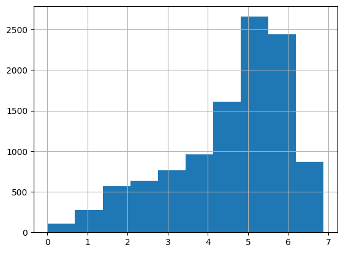

```python
log_count = np.log(train['count'])
log_count.hist()
```

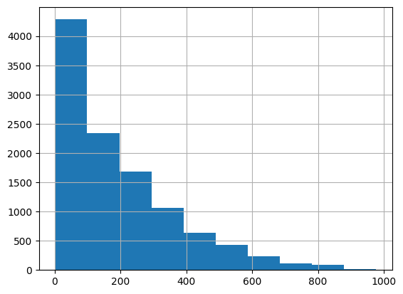

```python
train['count'].hist()
```

```python
train_ln_transform = train
train_ln_transform['count'] = log_count
```

#### since we achieved the best score with autostack on, let's try this setting on the ln transform of the count label

```python
predictor_transform_autostack = TabularPredictor(label = 'count', eval_metric = 'root_mean_squared_error').fit(
    train_data = train_ln_transform,
    time_limit = 600,
    presets = "best_quality",
    auto_stack = True
)
```

```
No path specified. Models will be saved in: "AutogluonModels/ag-20230108_215208/"
Presets specified: ['best_quality']
Stack configuration (auto_stack=True): num_stack_levels=1, num_bag_folds=8, num_bag_sets=20
Beginning AutoGluon training ... Time limit = 600s
AutoGluon will save models to "AutogluonModels/ag-20230108_215208/"
AutoGluon Version:  0.6.1
Python Version:     3.9.13
Operating System:   Linux
Platform Machine:   x86_64
Platform Version:   #1 SMP Wed Oct 26 20:36:53 UTC 2022
Train Data Rows:    10886
Train Data Columns: 12
Label Column: count
Preprocessing data ...
AutoGluon infers your prediction problem is: 'regression' (because dtype of label-column == float and many unique label-values observed).
	Label info (max, min, mean, stddev): (6.884486652042782, 0.0, 4.55256, 1.48904)
	If 'regression' is not the correct problem_type, please manually specify the problem_type parameter during predictor init (You may specify problem_type as one of: ['binary', 'multiclass', 'regression'])
Using Feature Generators to preprocess the data ...
Fitting AutoMLPipelineFeatureGenerator...
	Available Memory:                    14904.01 MB
	Train Data (Original)  Memory Usage: 0.89 MB (0.0% of available memory)
	Inferring data type of each feature based on column values. Set feature_metadata_in to manually specify special dtypes of the features.
	Stage 1 Generators:
		Fitting AsTypeFeatureGenerator...
			Note: Converting 2 features to boolean dtype as they only contain 2 unique values.
	Stage 2 Generators:
		Fitting FillNaFeatureGenerator...
	Stage 3 Generators:
		Fitting IdentityFeatureGenerator...
		Fitting CategoryFeatureGenerator...
			Fitting CategoryMemoryMinimizeFeatureGenerator...
		Fitting DatetimeFeatureGenerator...
	Stage 4 Generators:
		Fitting DropUniqueFeatureGenerator...
	Types of features in original data (raw dtype, special dtypes):
		('category', []) : 2 | ['season', 'weather']
		('datetime', []) : 1 | ['datetime']
		('float', [])    : 3 | ['temp', 'atemp', 'windspeed']
		('int', [])      : 6 | ['holiday', 'workingday', 'humidity', 'month', 'day', ...]
	Types of features in processed data (raw dtype, special dtypes):
```

[output cut: 82 more lines]

```
	-0.2852	 = Validation score   (-root_mean_squared_error)
	8.64s	 = Training   runtime
	0.98s	 = Validation runtime
Fitting model: NeuralNetFastAI_BAG_L2 ... Training model for up to 13.23s of the 13.21s of remaining time.
	Fitting 8 child models (S1F1 - S1F8) | Fitting with ParallelLocalFoldFittingStrategy
	-0.2946	 = Validation score   (-root_mean_squared_error)
	22.29s	 = Training   runtime
	0.97s	 = Validation runtime
Completed 1/20 k-fold bagging repeats ...
Fitting model: WeightedEnsemble_L3 ... Training model for up to 360.0s of the -14.39s of remaining time.
	-0.2801	 = Validation score   (-root_mean_squared_error)
	0.55s	 = Training   runtime
	0.0s	 = Validation runtime
AutoGluon training complete, total runtime = 614.96s ... Best model: "WeightedEnsemble_L3"
TabularPredictor saved. To load, use: predictor = TabularPredictor.load("AutogluonModels/ag-20230108_215208/")
```

```python
predictor_transform_autostack.fit_summary()
```

```
*** Summary of fit() ***
Estimated performance of each model:
                     model  score_val  pred_time_val    fit_time  pred_time_val_marginal  fit_time_marginal  stack_level  can_infer  fit_order
0      WeightedEnsemble_L3  -0.280094      14.600851  516.665521                0.000870           0.546727            3       True         17
1          CatBoost_BAG_L2  -0.282300      12.162794  455.123175                0.170975          90.948841            2       True         14
2          LightGBM_BAG_L2  -0.282778      12.198055  378.989076                0.206236          14.814741            2       True         12
3     ExtraTreesMSE_BAG_L2  -0.285220      12.967439  372.813785                0.975621           8.639451            2       True         15
4      WeightedEnsemble_L2  -0.285299      10.773058  291.564572                0.001509           1.342765            2       True         10
5        LightGBMXT_BAG_L2  -0.286191      12.281024  379.429952                0.289205          15.255618            2       True         11
6   RandomForestMSE_BAG_L2  -0.288644      12.896027  389.038548                0.904208          24.864214            2       True         13
7          CatBoost_BAG_L1  -0.291100       0.166778  225.272907                0.166778         225.272907            1       True          6
8   NeuralNetFastAI_BAG_L2  -0.294596      12.957945  386.460143                0.966126          22.285809            2       True         16
9          LightGBM_BAG_L1  -0.297667       1.691970   17.949326                1.691970          17.949326            1       True          4
10       LightGBMXT_BAG_L1  -0.304077       6.864467   30.192506                6.864467          30.192506            1       True          3
11          XGBoost_BAG_L1  -0.310975       0.399400    9.059360                0.399400           9.059360            1       True          9
12    ExtraTreesMSE_BAG_L1  -0.317983       1.023090    5.910870                1.023090           5.910870            1       True          7
13  RandomForestMSE_BAG_L1  -0.321837       0.950653   10.845120                0.950653          10.845120            1       True          5
14  NeuralNetFastAI_BAG_L1  -0.361231       0.759704   64.834248                0.759704          64.834248            1       True          8
15   KNeighborsDist_BAG_L1  -0.532997       0.074592    0.051077                0.074592           0.051077            1       True          2
16   KNeighborsUnif_BAG_L1  -0.670892       0.061166    0.058920                0.061166           0.058920            1       True          1
Number of models trained: 17
Types of models trained:
{'StackerEnsembleModel_KNN', 'StackerEnsembleModel_XGBoost', 'StackerEnsembleModel_CatBoost', 'StackerEnsembleModel_NNFastAiTabular', 'StackerEnsembleModel_RF', 'StackerEnsembleModel_LGB', 'WeightedEnsembleModel', 'StackerEnsembleModel_XT'}
Bagging used: True  (with 8 folds)
Multi-layer stack-ensembling used: True  (with 3 levels)
Feature Metadata (Processed):
(raw dtype, special dtypes):
('category', [])             : 2 | ['season', 'weather']
('float', [])                : 3 | ['temp', 'atemp', 'windspeed']
('int', [])                  : 4 | ['humidity', 'month', 'day', 'hour']
('int', ['bool'])            : 2 | ['holiday', 'workingday']
('int', ['datetime_as_int']) : 5 | ['datetime', 'datetime.year', 'datetime.month', 'datetime.day', 'datetime.dayofweek']
*** End of fit() summary ***
```

[output not shown]

[output cut: 163 more lines]

[output not shown]

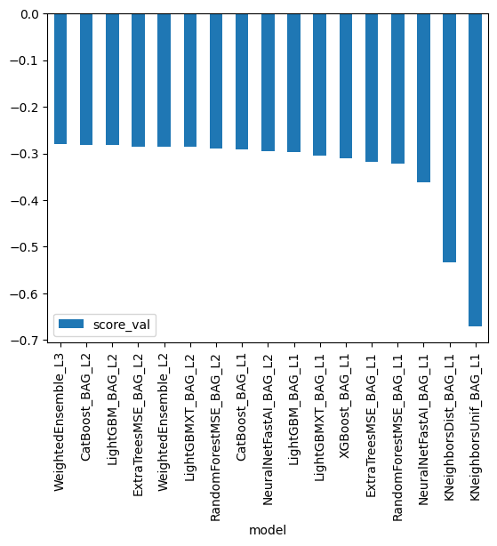

```python
predictor_transform_autostack.leaderboard(silent=True).plot(kind='bar', x='model', y='score_val')
```

```python
test_transform = predictor_transform_autostack.predict(test)
```

```python
#exponentiate count to undo ln transform
test_transform = np.exp(test_transform)
```

```python
#make submission file
submission_transform = submission
submission_transform['count'] = test_transform
submission_transform.to_csv('submission_transform.csv',index=False)
```

```python
#submit to kaggle
!kaggle competitions submit -c bike-sharing-demand -f submission_transform.csv -m "with features, autostack on, ln transform of count"
```

```
Successfully submitted to Bike Sharing Demand
```

```python
!kaggle competitions submissions -c bike-sharing-demand | tail -n +1 | head -n 2
```

kaggle score after performing ln transform: 0.56869